# MPDW Praktikum P4

# White Noise

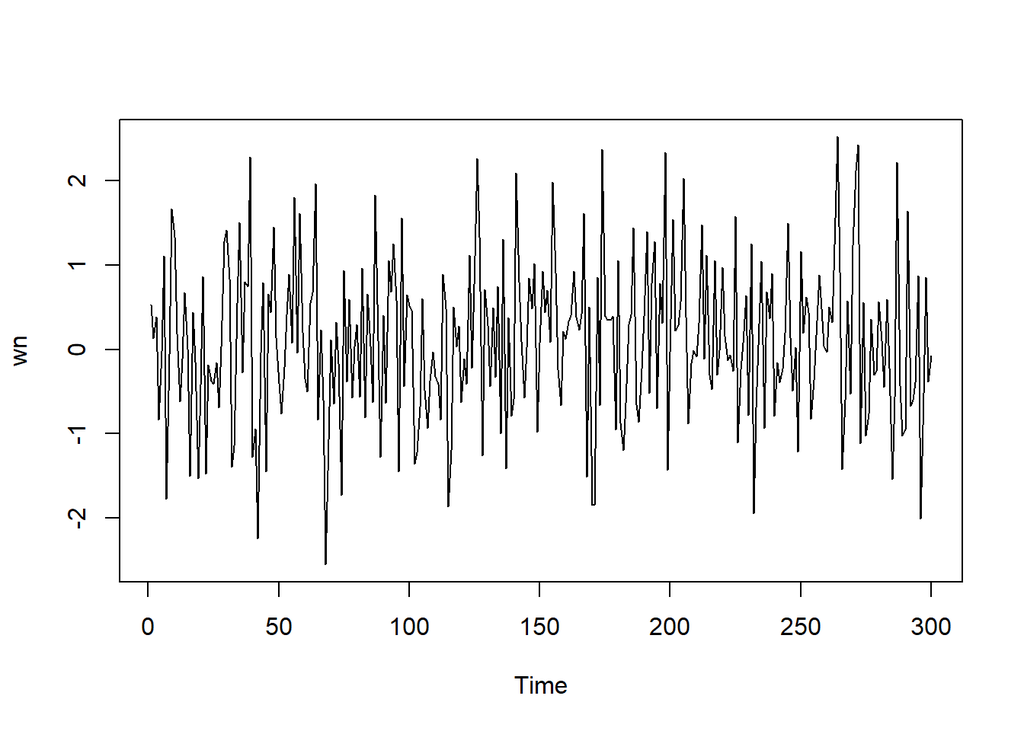

```r
set.seed(1043)
wn <- rnorm(300)
ts.plot(wn)
```

# MA(2)

Proses MA dapat dituliskan sebagai berikut:

$$y_{t} = c + e_t + \theta_{1}e_{t-1} + \theta_{2}e_{t-2} + \dots +
\theta_{q}e_{t-q} = c+{e_t+\sum_{i=1}^p \theta_ie_{t-i}}$$

Terlihat bahwa $e_t$, atau *white noise*, berperan penting dalam pembangkitan proses MA.

## Pembangkitan

### Pembangkitan secara Manual

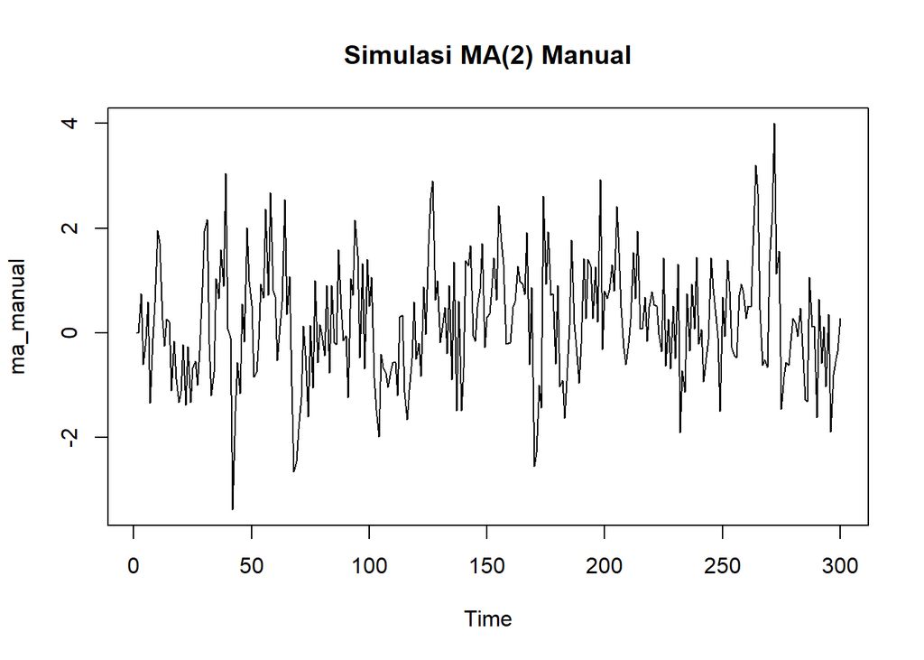

```r
set.seed(1043)
wn <- rnorm(300)   # white noise
ma_manual <- rep(0, 300)

for(i in 3:300){
  ma_manual[i] <- wn[i] + 0.4*wn[i-1] + 0.6*wn[i-2]
}
ts.plot(ma_manual, main="Simulasi MA(2) Manual")
```

Sebelum membangkitkan data MA(2), diberikan seed(1043) agar hasil data bangkitan konsisten dan tidak berubah-ubah. Sesuai ketentuan yang diberikan, data yang dibangkitkan akan memiliki persamaan:

$$y_t = e_t+0.4e_{t-1}+0.6e_{t-2}$$

### Pembangkitan dengan Function `arima.sim()`

Selain menggunakan cara di atas, pembangkitan proses MA(2) dapat dilakukan dengan fungsi `arima.sim()` sebagai berikut.

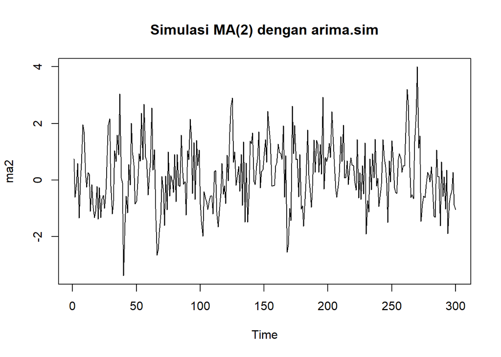

```r
set.seed(1043)
ma2 <- arima.sim(list(order=c(0,0,2), ma=c(0.4, 0.6)), n=300)
ts.plot(ma2, main="Simulasi MA(2) dengan arima.sim")
```

## Karakteristik MA(2)

### Plot Time Series

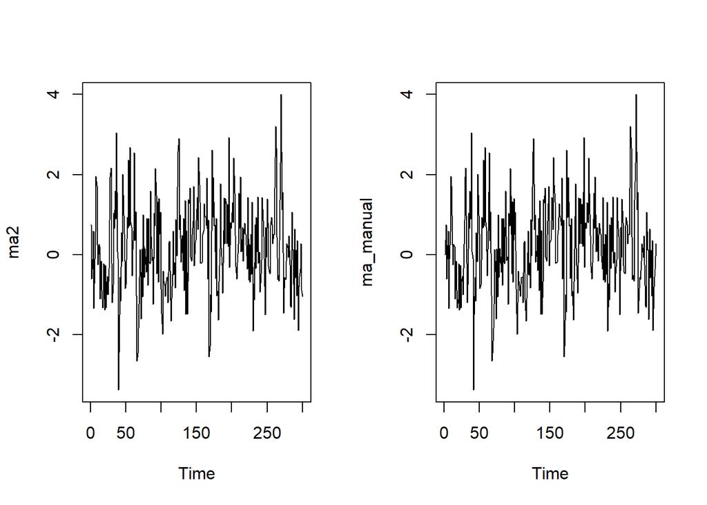

```r
par(mfrow = c(1, 2))
ts.plot(ma2)
ts.plot(ma_manual)
```

Berdasarkan plot time series, terlihat bahwa data MA(2) menyebar disekitar 0 dan memiliki keragaman yang cenderung homogen sehingga bisa dikatakan stasioner dalam rataan.

### Plot ACF

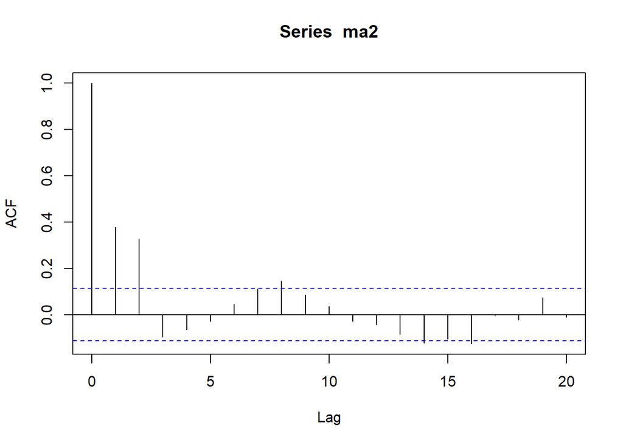

```r
acf(ma2,lag.max = 20)
```

Berdasarkan plot ACF tersebut, terlihat bahwa plot ACF *cuts off* di lag Kedua

### Plot PACF

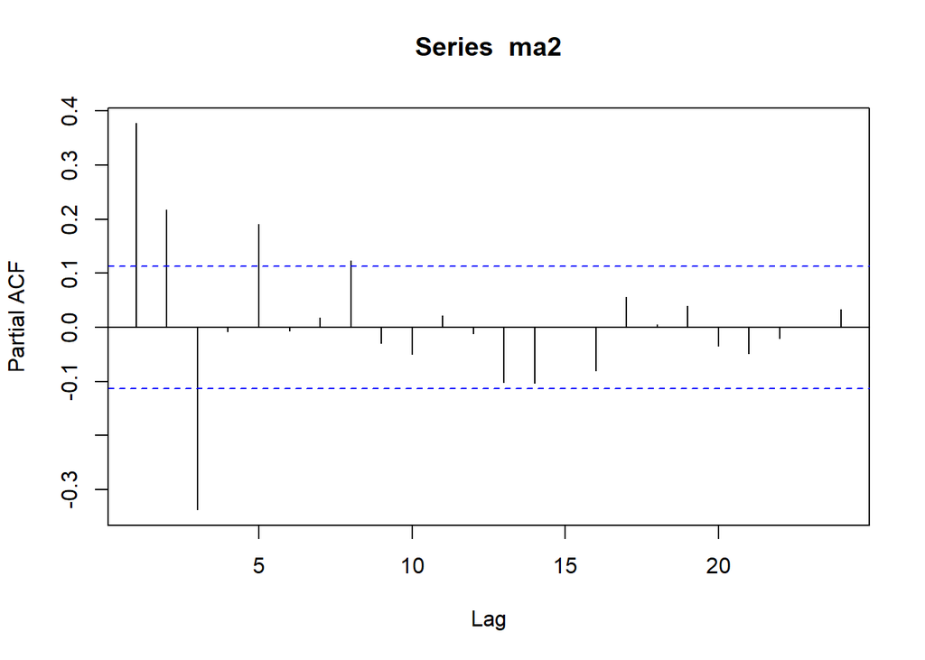

```r
pacf(ma2)
```

Berdasarkan plot PACF tersebut, terlihat bahwa plot PACF cenderung *tails off* dan membentuk gelombang sinus.

### Plot EACF

```r
TSA::eacf(ma2)
```

```
## AR/MA
##   0 1 2 3 4 5 6 7 8 9 10 11 12 13
## 0 x x o o o o o x o o o  o  o  x
## 1 x x x o o o o o o o o  o  o  o
## 2 x x x o o o o o o o o  o  o  o
## 3 o x x x o o o o o o o  o  o  o
## 4 o x x x x o o o o o o  o  o  o
## 5 o o x x o o x o o o o  o  o  o
## 6 x o x x x o x o o o o  o  o  o
## 7 x x x x x o o x o o o  o  o  o
```

Berdasarkan pola segitiga nol pada plot EACF, terlihat bahwa segitiga nol berada pada ordo AR(0) dan ordo MA(2)

## Scatterplot Antar Lag

### Korelasi antara $Y_t$ dengan $Y_{t-1}$

```r
#Yt
yt_ma <- ma2[-1]
head(yt_ma)
```

```
## [1] -0.6018763 -0.1226227  0.5930604 -1.3429174 -0.1034081  0.5810042
```

```r
#Yt-1
yt_1_ma <- ma2[-300]
head(yt_1_ma)
```

```
## [1]  0.7541216 -0.6018763 -0.1226227  0.5930604 -1.3429174 -0.1034081
```

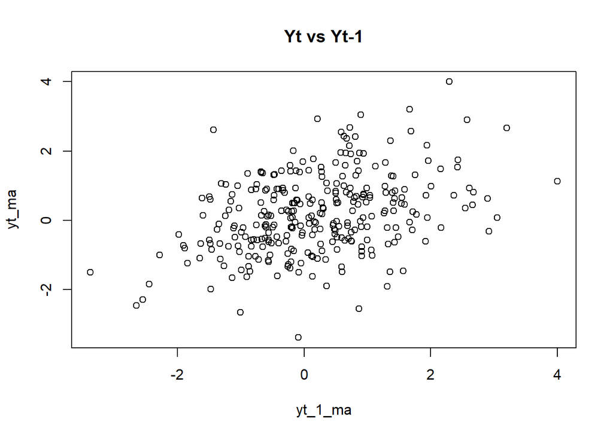

```r
plot(y=yt_ma,x=yt_1_ma, main="Yt vs Yt-1")
```

Berdasarkan scatterplot tersebut, terlihat bahwa terdapat hubungan positif antara $Y_t$ dengan $Y_{t-1}$. Hal ini sesuai dengan teori yang ada

```r
cor(yt_ma,yt_1_ma)
```

```
## [1] 0.3776918
```

Korelasi antara $Y_t$ dengan $Y_{t-1}$ dari hasil simulasi mendekati perhitungan teoritis yaitu

$$\rho_1=\frac{\theta_1+\theta_1\theta_2}{1+(\theta_1)^2+(\theta_2)^2}=\frac{0.4+(0.4)(0.6)}{1+(0.4)^2+(0.6)^2}=0.4211
\\
\rho_k = 0\ untuk\ k>2$$

### Korelasi antara $Y_t$ dengan $Y_{t-2}$

```r
#Yt
yt_ma2 <- ma2[-c(1,2)]
head(yt_ma2)
```

```
## [1] -0.1226227  0.5930604 -1.3429174 -0.1034081  0.5810042  1.9585130
```

```r
#Yt-2
yt_2_ma <- ma2[-c(299,300)]
head(yt_2_ma)
```

```
## [1]  0.7541216 -0.6018763 -0.1226227  0.5930604 -1.3429174 -0.1034081
```

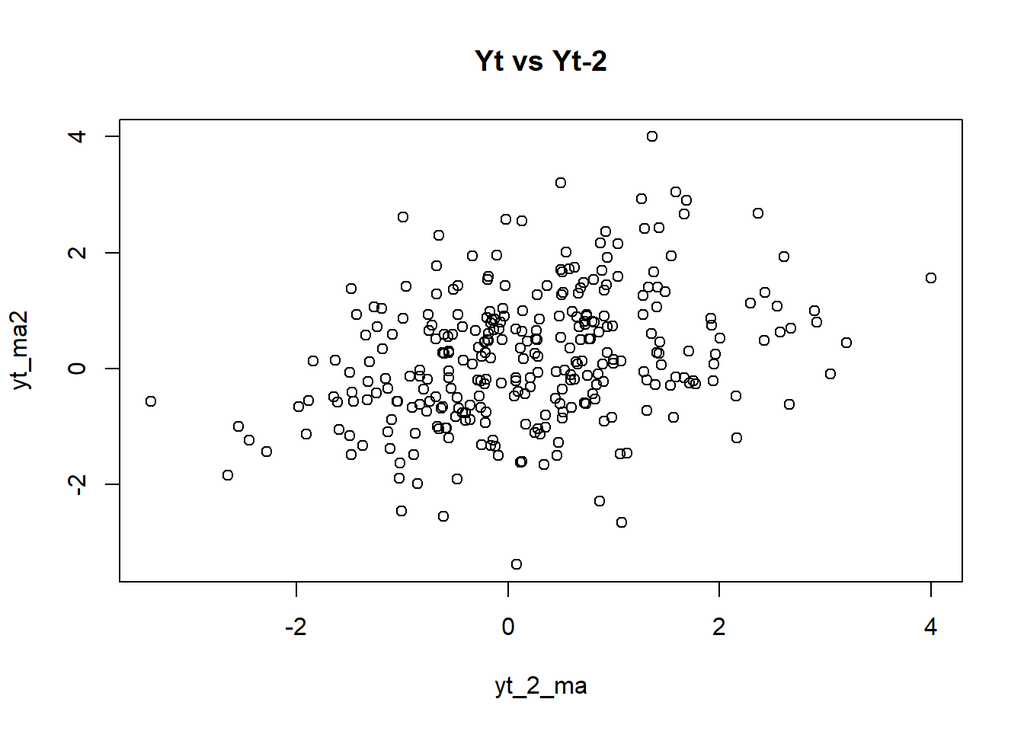

```r
plot(y=yt_ma2,x=yt_2_ma, main="Yt vs Yt-2")
```

Berdasarkan scatterplot tersebut, terlihat bahwa terdapat hubungan positif antara $Y_t$ dengan $Y_{t-2}$.Model MA(2) secara teoretis memiliki autokorelasi yang tidak nol pada lag 2. Scatter plot ini adalah bukti visual dari autokorelasi tersebut.

```r
cor(yt_ma2,yt_2_ma)
```

```
## [1] 0.3295534
```

Korelasi antara $Y_t$ dengan $Y_{t-2}$ hasil simulasi menunjukkan korelasi lag 2 sebesar 0.3295534 (nilai yang jauh dari nol) adalah bukti yang mendukung bahwa data tersebut memang berasal dari proses MA(2).

$$\rho_2 =
\frac{\theta_2}{1+\theta_1^2+\theta_2^2} = \frac{0.6}{1 + (0.4)^2 +
(0.6)^2} = \frac{0.6}{1.52} = 0.3947$$

### Korelasi antara $Y_t$ dengan $Y_{t-3}$

```r
#Yt
yt_ma3 <- ma2[-c(1,2,3)]
head(yt_ma3)
```

```
## [1]  0.5930604 -1.3429174 -0.1034081  0.5810042  1.9585130  1.7138816
```

```r
#Yt-2
yt_3_ma <- ma2[-c(298,299,300)]
head(yt_3_ma)
```

```
## [1]  0.7541216 -0.6018763 -0.1226227  0.5930604 -1.3429174 -0.1034081
```

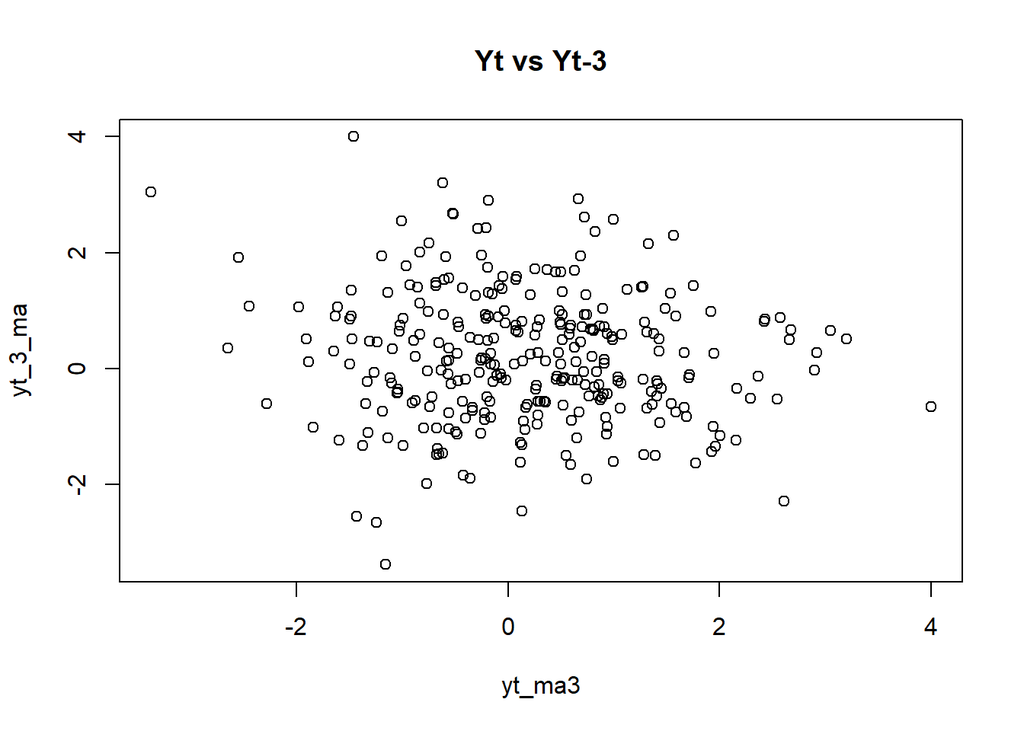

```r
plot(yt_ma3,yt_3_ma , main="Yt vs Yt-3")
```

Berdasarkan scatterplot tersebut, terlihat bahwa polanya menyebar acak dan cenderung tidak terdapat hubungan antara $Y_t$ dengan $Y_{t-3}$.

```r
cor(yt_ma3, yt_3_ma)
```

```
## [1] -0.09770875
```

Korelasi antara $Y_t$ dengan $Y_{t-3}$ hasil simulasi sebesar -0.0977 sangat mendekati teori yang ada, yaitu 0. Hal ini sejalan dengan teori model MA(2) di mana autokorelasi teoretisnya pada lag 3 adalah nol $\rho_3=0$.

# AR (2)

Proses AR dapat dituliskan sebagai berikut:

$$y_{t} = c + e_t + \phi_{1}Y_{t-1} +
\phi_{2}Y_{t-2} + \dots + \phi_{q}Y_{t-q} = c+{e_t+\sum_{i=1}^p
\phi_iY_{t-i}}$$
Terlihat bahwa $Y_t$ berperan penting dalam pembangkitan proses AR.

## Pembangkitan Proses AR

Nilai-nilai selanjutnya dapat dicari melalui *loop*. Bentuk loop dapat dilihat dari rumus AR(2) yang hendak dibangkitkan:

$$Y_t = e_t + 0.5Y_{t-1} + 0.2Y_{t-2}$$

### Pembangkitan Manual

```r
set.seed(1043)
n <- length(wn)
ar_manual <- numeric(n)

ar_manual[1] <- wn[1]
ar_manual[2] <- wn[2] + 0.5 * ar_manual[1]

for (i in 3:n) {
  ar_manual[i] <- wn[i] + 0.5 * ar_manual[i-1] + 0.2 * ar_manual[i-2]
}

head(ar_manual)
```

```
## [1]  0.52693900  0.39319879  0.68805369 -0.41147389 -0.08873265  0.97512615
```

### Pembangkitan dengan fungsi `arima.sim()`

```r
# Membangkitkan model AR(2)
ar_sim <- arima.sim(list(order = c(2,0,0), ar = c(0.5, 0.2)), n = 300)
head(ar_sim, 10)
```

```
##  [1] -1.05350535 -1.47180225 -0.91627804  0.52037888  1.48731189  1.68185195
##  [7] -0.25157477 -0.93010454  0.02903416  1.33286985
```

## Karakteristik AR(2)

### Plot Time Series

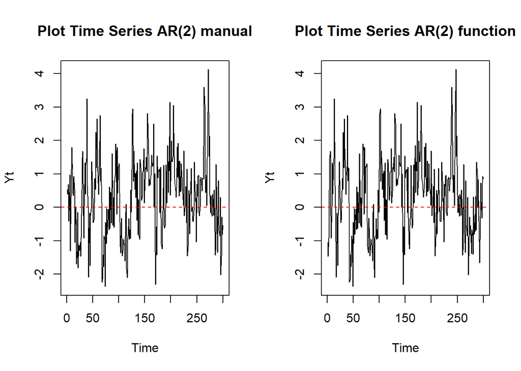

```r
par(mfrow = c(1, 2))
ts.plot(ar_manual, main="Plot Time Series AR(2) manual", ylab="Yt")
abline(h=0, col="red", lty=2)
ts.plot(ar_sim, main="Plot Time Series AR(2) function", ylab="Yt")
abline(h=0, col="red", lty=2)
```

Berdasarkan plot time series tersebut terlihat bahwa data cenderung stasioner pada rataan

### Plot ACF

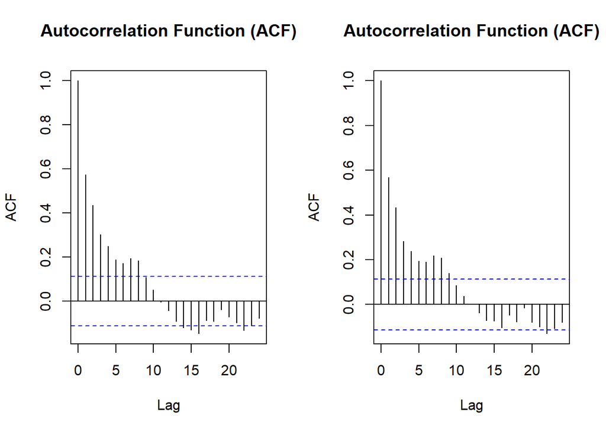

```r
par(mfrow = c(1, 2))
acf(ar_manual, main="Autocorrelation Function (ACF)")
acf(ar_sim, main="Autocorrelation Function (ACF)")
```

Berdasarkan plot ACF tersebut terlihat bahwa plot ACF cenderung *tails off*

### Plot PACF

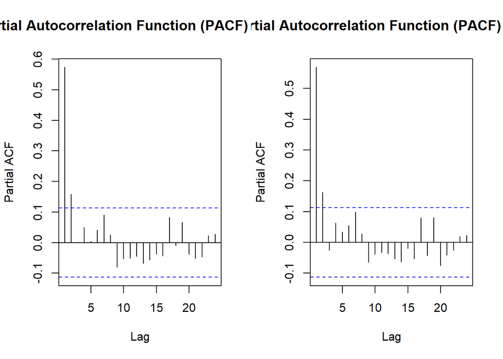

```r
par(mfrow = c(1, 2))
pacf(ar_manual, main="Partial Autocorrelation Function (PACF) Manual")
pacf(ar_sim, main="Partial Autocorrelation Function (PACF) Fungsi")
```

Berdasarkan plot PACF tersebut, terlihat bahwa plot PACF *cuts off* pada lag kedua, sejalan dengan teori yang ada.

### Plot EACF

```r
TSA::eacf(ar_manual)
```

```
## AR/MA
##   0 1 2 3 4 5 6 7 8 9 10 11 12 13
## 0 x x x x x x x x o o o  o  o  x
## 1 x o o o o o o o o o o  o  o  o
## 2 o x o o o o o o o o o  o  o  o
## 3 o x o o o o o o o o o  o  o  o
## 4 x x o o o o o o o o o  o  o  o
## 5 x o x o o o o o o o o  o  o  o
## 6 x o x o o x o o o o o  o  o  o
## 7 x x x o x o o x o o o  o  o  o
```

```r
TSA::eacf(ar_sim)
```

```
## AR/MA
##   0 1 2 3 4 5 6 7 8 9 10 11 12 13
## 0 x x x x x x x x x o o  o  o  o
## 1 x o o o o o o o o o o  o  o  o
## 2 x x o o o o o o o o o  o  o  o
## 3 x x o o o o o o o o o  o  o  o
## 4 x x o o o o o o o o o  o  o  o
## 5 x o x o o o o o o o o  o  o  o
## 6 x o x x o o o x o o o  o  o  o
## 7 x x x x o o x o o o o  o  o  o
```

Berdasarkan pola segitiga nol pada plot EACF, terlihat bahwa segitiga nol berada pada ordo AR(1) dan ordo MA(1). Tetapi ada Noise pada ordo AR(6) dan ordo MA(7).

### Scatterplot Antar Lag

#### Korelasi antara $Y_t$ dengan $Y_{t-1}$

```r
yt   <- ar_sim[-1]
yt_1 <- ar_sim[-300]
head(yt_1)
```

```
## [1] -1.0535054 -1.4718023 -0.9162780  0.5203789  1.4873119  1.6818520
```

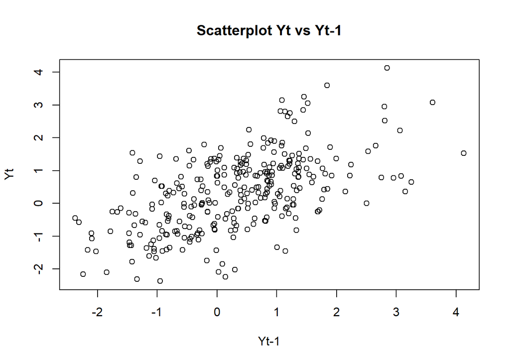

```r
plot(y=yt,x=yt_1, main="Scatterplot Yt vs Yt-1",
     xlab="Yt-1", ylab="Yt")
```

Terlihat dengan jelas adanya pola linear positif yang kuat. Ini mengindikasikan adanya autokorelasi positif yang sangat kuat pada lag 1.

```r
cor(yt,yt_1)
```

```
## [1] 0.5706262
```

Perhitungan teoritis yaitu $\rho_1=\phi_1 / (1 - \phi_2)=0.5 / (1 - 0.2) = 0.625$

#### Korelasi antara $Y_t$ dengan $Y_{t-2}$

```r
yt__2 <- ar_sim[-c(1,2)]
yt_2 <- ar_sim[-c(299,300)]
head(yt_2)
```

```
## [1] -1.0535054 -1.4718023 -0.9162780  0.5203789  1.4873119  1.6818520
```

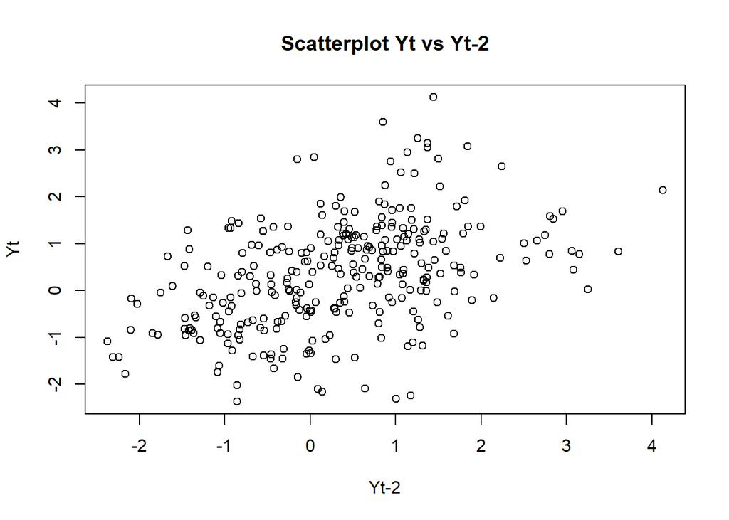

```r
plot(y=yt__2,x=yt_2, main="Scatterplot Yt vs Yt-2",
     xlab="Yt-2", ylab="Yt")
```

Berdasarkan scatterplot terlihat adanya pola linear positif, namun lebih lemah dan lebih tersebar dibandingkan dengan plot lag 1. Walaupun ada tren menaik, sebaran titiknya lebih luas. Ini menandakan adanya autokorelasi positif yang signifikan (namun tidak sekuat lag 1) pada lag 2.

```r
cor(yt__2,yt_2)
```

```
## [1] 0.4370927
```

Perhitungan Teoritisnya adalah sebagai berikut
$$\rho_2=\phi_1 * \rho_1 + \phi_2 *
\rho_0=(0.5)(0.625)+(0.2)(1)=0.5125$$

```r
yt__3 <- ar_sim[-c(1,2,3)]
yt_3 <- ar_sim[-c(298,299,300)]
head(yt_3)
```

```
## [1] -1.0535054 -1.4718023 -0.9162780  0.5203789  1.4873119  1.6818520
```

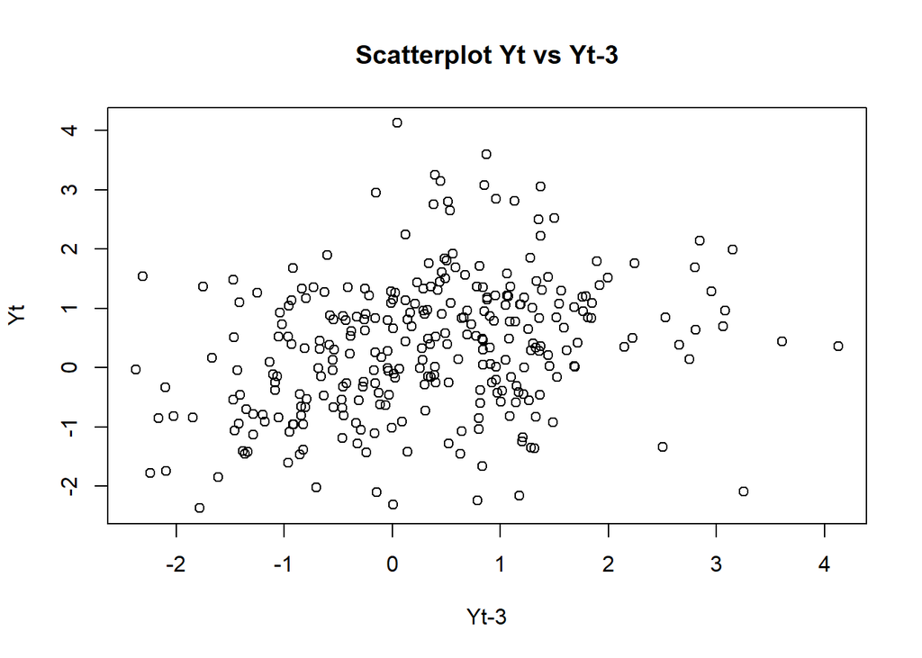

```r
plot(y = yt__3, x = yt_3, main="Scatterplot Yt vs Yt-3",
     xlab="Yt-3", ylab="Yt")
```

```r
cor(yt__3,yt_3)
```

```
## [1] 0.2853171
```

Perhitungan Teoritisnya adalah sebagai berikut
$$\rho_3=\phi_1\rho_2+\phi_2\rho_1=(0.5)(0.5125)+(0.2)(0.625)=0.38125$$

Korelasi antara $Y_t$ dengan $Y_t−3$ dari hasil simulasi, atau autokorelasi sampel lag 3 (r3), adalah sebesar 0.2853171. Nilai ini masih sejalan dengan nilai teoretisnya $\rho_3$ yaitu 0.38125.

```r
phi1 <- 0.5
phi2 <- 0.2

rho <- numeric(4)
rho[1] <- 1
rho[2] <- phi1 / (1 - phi2)
rho[3] <- phi1 * rho[2] + phi2 * rho[1]
rho[4] <- phi1 * rho[3] + phi2 * rho[2]

rho
```

```
## [1] 1.00000 0.62500 0.51250 0.38125
```

# ARMA (2,2)

## Pembangkitan Data

### Pembangkitan Manual

```r
set.seed(1043)
n <- 300
phi1 <- 0.5
phi2 <- 0.2
theta1 <- 0.4
theta2 <- 0.6

y.arma <- numeric(n)
y.arma[1:2] <- wn[1:2]

for (i in 3:n){
  y.arma[i] <- phi1 * y.arma[i-1] +
             phi2 * y.arma[i-2] +
             wn[i] +
             theta1 * wn[i-1] +
             theta2 * wn[i-2]
}

y.arma <- ts(y.arma)
head(y.arma)
```

```
## [1]  0.526938999  0.129729294  0.924374056 -0.113743435  0.005380349
## [6]  0.573001866
```

### Pembangkitan ARMA(2,2) dengan fungsi `arima.sim`

```r
set.seed(1043)
arma22_fungsi <- arima.sim(list(order=c(2,0,2), ma=c(0.4, 0.6), ar=c(0.5, 0.2)), n=300)
head(arma22_fungsi)
```

```
## [1] -2.13757866 -0.72957695  1.14541968  2.58879292  1.31339220 -0.02174598
```

## Karakteristik ARMA(2,2)

### Plot Time Series

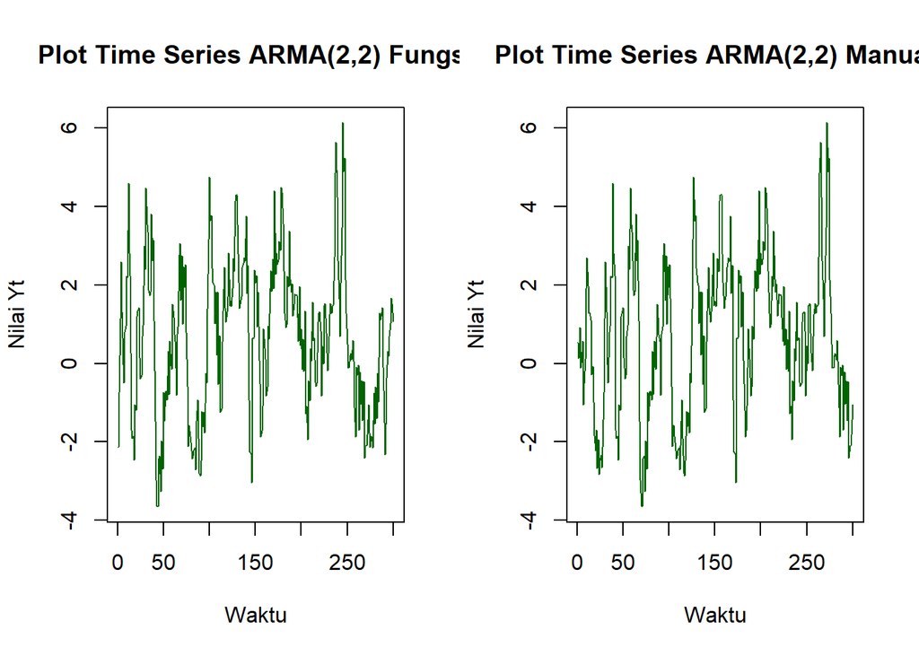

```r
par(mfrow = c(1, 2))
ts.plot(arma22_fungsi, main = "Plot Time Series ARMA(2,2) Fungsi",
     ylab = "Nilai Yt", xlab = "Waktu", col = "darkgreen")
ts.plot(y.arma, main = "Plot Time Series ARMA(2,2) Manual",
     ylab = "Nilai Yt", xlab = "Waktu", col = "darkgreen")
```

Berdasarkan plot time series tersebut, terlihat bahwa model ARMA(2,2) cenderung stasioner dalam rataan

### Plot ACF

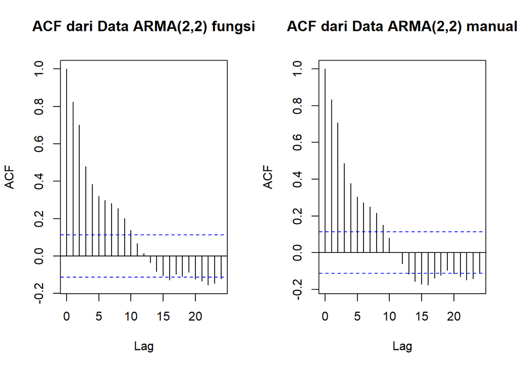

```r
par(mfrow=c(1, 2))
acf(arma22_fungsi, main="ACF dari Data ARMA(2,2) fungsi")
acf(y.arma, main="ACF dari Data ARMA(2,2) manual")
```

Berdasarkan plot ACF tersebut, terlihat bahwa model ARMA(2,2) hasil simulasi memiliki plot ACF yang *tails off* pada lag kedua dan seterusnya. Hal ini membuktikan bahwa data yang dibangkitkan memang ARMA(2,2) dan sesuai dengan teori yang ada dimana pada lag kedua hingga seterusnya nilai ACF akan menurun perlahan secara eksponensial.

### Plot PACF

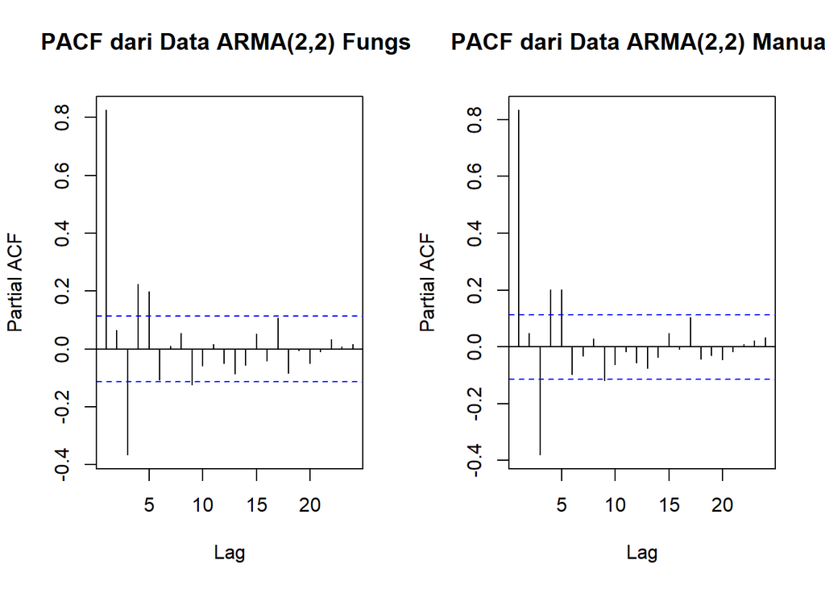

```r
par(mfrow = c(1, 2))
pacf(arma22_fungsi, main="PACF dari Data ARMA(2,2) Fungsi")
pacf(y.arma, main="PACF dari Data ARMA(2,2) Manual")
```

### Plot EACF

```r
TSA::eacf(y.arma)
```

```
## AR/MA
##   0 1 2 3 4 5 6 7 8 9 10 11 12 13
## 0 x x x x x x x x x o o  o  o  x
## 1 o x x o o o o x o o o  o  o  o
## 2 x x x o o o o o o o o  o  o  o
## 3 x x x x o o o o o o o  o  o  o
## 4 x x x x o x o o o o o  o  o  o
## 5 x x o x o o o o o o o  o  o  o
## 6 x x o x x o x x o o o  o  o  o
## 7 x o x x o x o o o o o  o  o  o
```

```r
TSA::eacf(arma22_fungsi)
```

```
## AR/MA
##   0 1 2 3 4 5 6 7 8 9 10 11 12 13
## 0 x x x x x x x x x x o  o  o  o
## 1 o x x o x o o o o o o  o  o  o
## 2 x x x o o o o o o o o  o  o  o
## 3 x x x x x o o o o o o  o  o  o
## 4 x x x x o o o o o o o  o  o  o
## 5 x x o x o o x o o o o  o  o  o
## 6 x x o x x o x x o o o  o  o  o
## 7 x o x x o o o o o o o  o  o  o
```

### Scatterplot Antar Lag

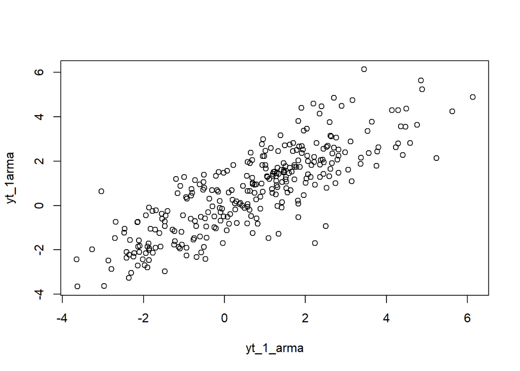

```r
yt_1arma <- arma22_fungsi[-1]
yt_1_arma <- arma22_fungsi[-300]
plot(y=yt_1arma,x=yt_1_arma)
```

Berdasarkan scatterplot tersebut, terlihat bahwa terdapat hubungan positif antara $Y_t$ dengan $Y_{t-1}$. Hal ini sesuai dengan teori yang ada

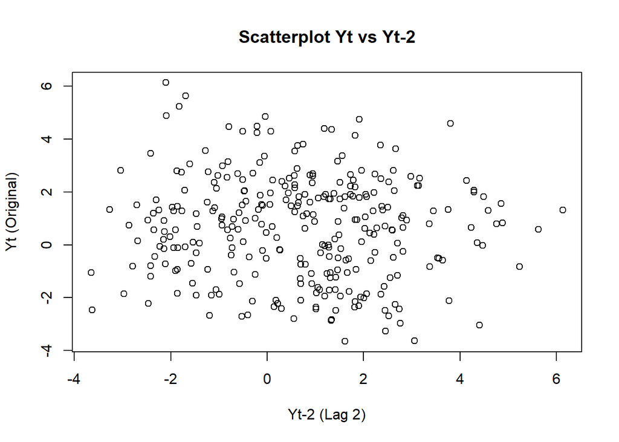

```r
yt_2arma <- y.arma[-c(1,2)]
yt_2_arma <- arma22_fungsi[-c(299, 300)]
plot(x = yt_2_arma, y = yt_2arma,
     main = "Scatterplot Yt vs Yt-2",
     xlab = "Yt-2 (Lag 2)",
     ylab = "Yt (Original)")
```

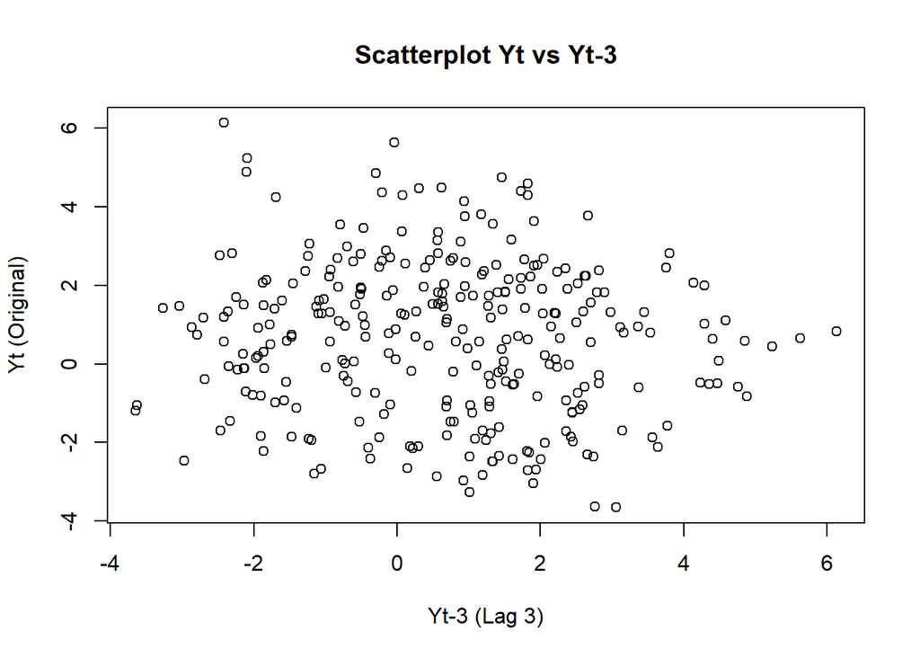

```r
yt_3arma <- y.arma[-c(1,2,3)]
yt_3_arma <- arma22_fungsi[-c(298, 299, 300)]
plot(x = yt_3_arma, y = yt_3arma,
     main = "Scatterplot Yt vs Yt-3",
     xlab = "Yt-3 (Lag 3)",
     ylab = "Yt (Original)")
```

```r
cor(yt_1arma,yt_1_arma)
```

```
## [1] 0.8280312
```

```r
cor(yt_2arma, yt_2_arma)
```

```
## [1] -0.06098376
```

```r
cor(yt_3arma, yt_3_arma)
```

```
## [1] -0.08718038
```

### Korelasi antara $Y_t$ dengan $Y_{t-1}$, $Y_{t-2}$, $Y_{t-3}$ Pakai Perhitungan Teoritis

```r
phi1  <- 0.5
phi2  <- 0.2
theta1 <- 0.4
theta2 <- 0.6
sigma2 <- 1

psi <- numeric(11)
psi[1] <- theta1 + phi1
psi[2] <- theta2 + phi1*psi[1] + phi2
for(k in 3:10){
  psi[k] <- phi1*psi[k-1] + phi2*psi[k-2]
}

gamma <- numeric(5)
for(k in 0:4){
  gamma[k+1] <- sigma2 * sum(psi[1:(11-k)] * psi[(1+k):11])
}

rho <- gamma / gamma[1]
rho[1:5]
```

```
## [1] 1.0000000 0.8464856 0.6184641 0.4722594 0.3516037
```